# DialogTree (d3) - Multiple Choice Dialogue Engine

Copyright © Jari Komppa

http://iki.fi/sol

# "DialogTree (d3) 20200125"

# Introduction

DialogTree is a engine for building dialogue trees with non-player characters in games. The way it works, it can also be used as basis for multiple choise adventures, visual novels and the like. Just be careful not to use the trademarked terms enforced by ChooseCo.

The d3 concept consists of several pieces. Each dialogue itself is called a "deck", where each scene is a "card" which contains a "question" field and zero or more "answer" fields. Each answer then tells which card should be read next.

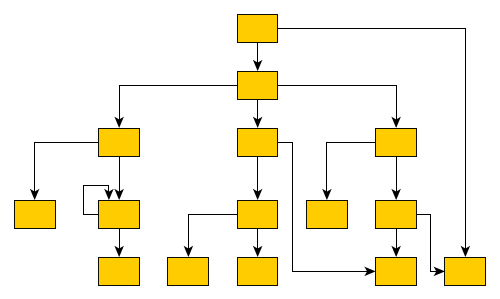

Think of each box as a page in a book, and at the bottom of each page you'll find something in the lines of, "Turn to page 32 if you want to..".

These "decks" are written in DialogTree story definition language. Large portion of this document covers this process. For most uses, the format is trivial, but DialogTree offers functionality to make very complicated dialogues.

The "deck" files are compiled to usable form with the d3 compiler. The resulting files are read by the d3 engine which can be integrated to your actual game engine, along with some form of persistent state.

## Legalese

DialogTree is released under Unlicense, which is basically public domain.

https://github.com/jarikomppa/d3

This is free and unencumbered software released into the public domain.

Anyone is free to copy, modify, publish, use, compile, sell, or distribute this software, either in source code form or as a compiled binary, for any purpose, commercial or non-commercial, and by any means.

In jurisdictions that recognize copyright laws, the author or authors of this software dedicate any and all copyright interest in the software to the public domain. We make this dedication for the benefit of the public at large and to the detriment of our heirs and successors. We intend this dedication to be an overt act of relinquishment in perpetuity of all present and future rights to this software under copyright law.

THE SOFTWARE IS PROVIDED "AS IS", WITHOUT WARRANTY OF ANY KIND, EXPRESS OR IMPLIED, INCLUDING BUT NOT LIMITED TO THE WARRANTIES OF MERCHANTABILITY, FITNESS FOR A PARTICULAR PURPOSE AND NONINFRINGEMENT. IN NO EVENT SHALL THE AUTHORS BE LIABLE FOR ANY CLAIM, DAMAGES OR OTHER LIABILITY, WHETHER IN AN ACTION OF CONTRACT, TORT OR OTHERWISE, ARISING FROM, OUT OF OR IN CONNECTION WITH THE SOFTWARE OR THE USE OR OTHER DEALINGS IN THE SOFTWARE.

For more information, please refer to

http://unlicense.org/

# DialogTree Story Definition Language

The DialogTree story definition language may sound scary, but it is actually very simple. The DialogTree scripts are plain text files, such as those that can be created with Windows Notepad, although the author recommends using something more advanced, such as UltraEdit, Sublime Text or Notepad++.

Not all of the features of the language are needed to write adventures; this document is structured so that more complicated features are described later, so you won't need to read all of it to get started. If something feels complicated, don't worry about it - you can come back to it later.

## Structure

Structure of a multiple choice adventure is based on pages (other used terms include rooms, locations, nodes). Each page consists of description part as well as zero or more choices for the user (also known as answers, selections, options).

Consider the computer asking the user a question, and offering several possible answers for the question.

The script for a simple page looks like this:

```
$Q roomname
The description of the room
$A otherroomname
Go to other room
```

The choices link pages together. Here we'll describe three rooms and let the user travel between them:

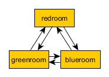

```
$Q redroom
You're in the red room.
$A greenroom
Go to the green room
$A blueroom
Go to the blue room

$Q greenroom
You're in the green room.
$A blueroom
Go to the blue room
$A redroom
Go to the red room

$Q blueroom
You're in the blue room.
$A greenroom
Go to the green room
$A redroom
Go to the red room
```

Everything between two $Q lines goes to a single page. The first word after the $Q and $A is the label of the room. In programming terms, you could think of it as GOTO label. Two rooms may not have the same label, but any number of $A lines may point to the same label. Labels may not include spaces (i.e, they need to be a single word).

It is also perfectly legal for a room to have an choice which goes back to the same page. This is actually rather useful.

If a room has no $A lines, it is considered an "end node", and the adventure ends if player ends up on that page.

### Text

The text in the page descriptions is automatically formatted, removing any unnecessary "white space" like line breaks or additional spaces. To start a new paragraph, add an empty line in your text.

```
All of
these go
on the
same line.

This is a new paragraph.

    Adding   more   spaces   does   nothing.
```

To add an empty line, use the $P line (see below).

### Comments

You can add comments in the script which do not end up in your adventure file by starting a line with the hash character.

```
# This is a comment
This is not a comment
```

### Paragraph Breaks

While the text is often expected to flow, sometimes empty lines may be desirable. To output an empty line, use the $P statement.

```
$Q fountain
You arrive at a picturesque fountain. Assume there's a long description here.
$P
You can see some mushrooms here.
```

## Flags

In addition to the basic structure of the pages, flags can be used to introduce more complicated behavior. By default, every time the player goes to a page, the flag with the page's name is turned on. Using these, an optional part can be added to a page's description.

```
$Q alleyway
You're in a dark alley. There's a door.
$P backyard
You remember seeing the bad guys inside when you were at the back yard.
```

In this example the "You remember.." line is only shown if the player has visited the backyard page before ending up here.

If you wish to have optional part of the text between two parts of text that is always shown, you can reset the optionality by using an empty $P line.

```
Text always shown
$P daytime
Text shown only during daytime
$P
Another text always shown
```

If you want to use optional paragraphs but do not want the newline, you can use $O in place of $P. In more complicated cases this can get a bit messy though, so it's usually a good idea to keep things simple.

### Checking Flags

You can check if a flag is on by using its label. You can also check if a flag is not on by prefixing the flag's label with an exclamation point (!), like !backyard.

```
$P daytime
The sun is shining.
$P !daytime
The moon is bright tonight.
```

Alternate syntax for this is to use the has: and not: prefixes.

```
$P has:daytime
The sun is shining.
$P not:daytime
The moon is bright tonight.
```

If you wish something to happen randomly, you can use the rnd: prefix with a value.

```
$P rnd:25
Thorin sits down and starts singing about gold.
```

The maximum value is 100, so a value of 50 gives about 50% chance, etc.

The flag checks can also be used with the $Q and $A lines.

If flag check is used with the $A line, the choice is only given to the player if the flag check succeeds.

```
$A mine has:cleared
Enter the mine through the cleared tunnel.
```

If flag check is used with the $Q line, any other commands on that same line are only executed if the flag check is positive. (See below for the other commands).

### Setting Flags

To set a flag, use the set: prefix with a flag label.

```
$A alleyway set:trapped
Place the trap just outside the door.
```

Setting a flag that is already on is legal, but has no effect.

### Clearing Flags

You can also clear flags, including the ones set by visiting a page. This is done with the clear: or clr: command.

```
$A alleyway clear:trapped
Change your mind, and clear the trap from the door.
```

Clearing a flag that is not on is legal, but has no effect.

### Toggling Flags

Flags can be toggled with the toggle: command. This way you don't need to know which state the flag is in, if you wish to switch between two states.

```
$Q busystreet toggle:trafficlights
$P trafficlights
The traffic lights are red.
$P !trafficlights
The traffic lights are green.

$A busystreet
Wait for a while
$A sleepytown !trafficlights
Cross the street
```

## Numbers

Sometimes it's useful to handle numbers instead. Many gamebooks have concept of hit points, for instance.

### Setting Numbers

To set the value of a number, use the = operator.

```
$A fountain hitpoints=7
Drink from the fountain
```

You can set a number variable to the value of another variable or to a fixed value.

```
$A tavern temp=player_money player_money=stranger_money stranger_money=temp
Swap purses with the stranger
```

### Adding and Subtracting Numbers

Adding and subtracting are done with the - and + operators.

```
$A fountain hitpoints-1
Eat a mushroom
$A fountain hitpoints+1
Eat a biscuit
```

Again, fixed values or other variables can be used.

```
$A fountain hitpoints+potion potion-1 potion>0
Drink from the healing potion
```

If you prefer, you can use -= and += instead of - and +:

```
$A fountain score+=3 darts-=1 darts>0
Throw a dart at the board
```

### Comparing Numbers

Numeric variables can be compared in various ways, to each other and to fixed numbers.

```
$O a==42
a is 42
$O a!=42
a is not 42
$O a>42
a is bigger than 42
$O a>=42
a is bigger or equal to 42
$O a<42
a is smaller than 42
$O a<=42
a is smaller or equal to 42
```

Note that a=1 means "assign 1 to a", while a==1 means "is a equal to 1".

As you might expect, it's also possible to compare two variables.

```
$O a==b
a is equal to b
$O a!=b
a is not equal to b
$O a>b
a is bigger than b
$O a>=b
a is bigger or equal to b
$O a<b
a is smaller than b
$O a<=b
a is smaller or equal to b
```

Here again, a=b means "assign a to value of b" and a==b means "is a equal to b".

When comparing a varialbe with a number, the variable must always be the first parameter, i.e, you can't do 3==pi.

### Printing Numbers

It is also possible to print out the values of the numeric variables, by simply putting the variable name between << and >> in the text. Note that there must be no spaces between these characters.

```
$Q store
The shopkeeper polishes an apple while he's waiting for you
to make a selection. You currently have <<gold>> gold.
$A store gold>5 gold-5 set:dagger
Buy the dagger for 5 gold
```

Alternatively it's possible to use the print command:

```
You have
$O print:gold
gold pieces.
```

This is basically what the compiler turns the "inline" number printing to. This can cause issued with voiceover and/or localization efforts, so use the number printing with caution.

### Mixing Flags and Numbers

Numbers and flags do not mix. If you try to assign flag to a numeric variable, for instance, it won't do what you expect:

```
$O set:parrot
$O bird=parrot
```

This will create a new numeric variable called "parrot", which will live alongside the flag "parrot". The compiler will warn you if you try to do this.

## Go and Gosub

Sometimes it is useful to interrupt the normal page flow and do something else for a change.

For example, if your game has a hit point mechanism, it would be wasteful to add checking if the player has died on every single page.

```
$Q healthcheck
$P hitpoints==0 go:dead
$P hitpoints<5
You're not feeling too good.

$Q fountain
The fountain.
$O gosub:healthcheck
You find yourself near a marble fountain in the forest
clearing. There are some mushrooms nearby.
```

In the example above, whenever the player arrives at the "fountain" page, the game will load the healthcheck page, which will first check if player is dead, and if so, will turn to the "dead" page immediately. If the player is still alive, the page will output the "You're not feeling too good" message if hitpoints are low. Otherwise the processing of that sub-page is done and drawing of the "fountain" page resumes from where we were at.

Subpages can also not have any $A statements; if any exist, they will be ignored.

## Deck Configuration

DialogTree has special statement that can be used to configure the way the deck works.

```
$C prefix
```

The first parameter to the $C statement is the deck's prefix. All of the local symbols in the deck are prefixed with this string before they're sent to the persistent state. The prefix can be followed by other options. Currently only two options exist:

| Option | Description |
| --- | --- |
| noimplicitflags | Disable flag setting upon entering a card |
| implicitflags | Enable flag setting upon entering a card |

By default, DialogTree sets a flag with the same name as the card. This behavior can be enabled or disabled. If the option is enabled or disabled on command line, this option overrides it.

## Global Pages

Sometimes it's useful to have a card that is evaluated at the start of every other card.

```
$G symbol
```

This is functionally identical to having gosub:symbol at the start of every other $Q statement.

## More Technically Speaking

Here's some a bit more technical notes which may be useful in problematic cases.

### Command Execution Order

To get a little bit more nitty-gritty, here's a few words about command execution order.

Commands are, generally speaking, executed in the order they're set. In the following example, foo is set to 1, and then we go to another page, which means the foo=2 instruction is never executed:

```
$O foo=1 goto:elsewhere foo=2
```

However, flag check is always performed first, and only if the whole flag check succeeds, the other commands are executed. Thus, if you write something as convoluted as:

```
$O set:flaggy flaggy clear:flaggy toggle:flaggy
```

what happens is:

```
If flaggy is on:
    Set flaggy
    Clear flaggy
    Toggle flaggy
```

Another example, just to be sure:

```
$O attr=7 apple cls=1 banana rnd:25 orange set:strawberry
```

This becomes:

```
If apple is on, and banana is on,
and random is less than 25 and orange is on:
    Set attr to 7
    Set cls to 1
    Set strawberry
```

To reiterate: first everything that affects whether the line should be executed is evaluated, and only then the rest are executed, assuming all of those things turn out to be true.

If any of the checks fail, the rest are not executed.

In case of $A blocks, the answer is included if it produces any text (i.e, if there is at least one paragraph that is not predicated away), but the commands are only executed when the option is selected.

### Go and Gosub Revisited

The exact point at which the go and gosub commands are executed is exactly where the opcode is:

```
$Q mysubpage
Hello

$Q normalpage
$O gosub:mysubpage
World
```

..will output Hello World.

Using the go: command will send the player to a new page just as if they had selected an option: the room's flag will be set, the screen cleared, etc. The jump happens at the place where the opcode is, meaning that the rest of the opcodes (if any) as well as the rest of the page, including any $A blocks, is ignored.

### The $P vs the $O Statement

The $O and $P statements work exactly the same, except that when the compiler finds an $O statement, it will look back to the previous paragraph and will remove any newlines from the end of it. This works fairly well in simple cases, but if you find yourself chaining several predicated $O and $P blocks, things may get confusing.

### Using Several Source Files

It is possible to split source files into several pieces and combine them with the $I statement. If you find you want to include some piece of text (or logic!) in several decks, this can be done by using this include statement.

```
The troll takes a deep breath, and says:
$I legalese.txt
```

The $I statement works exactly as if you copy-pasted the file on that line.

### Using Several Decks

Since all decks talk with the same persistent state, keeping track of the symbols can be rather difficult. Every deck can have a prefix set using the config statement:

```
$C prefix
```

This will turn every local symbol to a global one. For example, if you have a deck with prefix "joe", and you set the symbol "grateful", the symbol that actually gets set in the state is called "joe.grateful". If you refer to a symbol with a period in it, the prefix is not set. Thus, you can take your deck with prefix "lisa" and check if joe is grateful by referring to the "joe.grateful" tag.

It is also possible to have several decks with the same prefix. This can be useful if you have several discussions with the same NPC, and don't want to put all of the text into a single source file.

## Opcode reference

Here's all the opcodes in handy table form. In many cases there are several ways to do the same thing.

### Predicates - Flags

| Opcode | Description |
| --- | --- |
| has:symbol | Check if a symbol is set |
| need:symbol |  |
| symbol |  |
| not:symbol | Check if a symbol is not set |
| !symbol |  |

### Predicates - Random

| Opcode | Description |
| --- | --- |
| random:value | Take random number in 0..99 range and compare it to given value |
| rand:value |  |
| rnd:value |  |

### Predicates - Numeric

| Opcode | Description |
| --- | --- |
| symbol==value | Check if symbol's value is equal to value |
| symbol==symbol | Check if symbol's value is equal symbol's value |
| symbol!=value | Check if symbol's value is not equal to value |
| symbol!=symbol | Check if symbol's value is not equal symbol's value |
| symbol<value | Check if symbol's value is less than value |
| symbol<symbol | Check if symbol's value is less than symbol's value |
| symbol<=value | Check if symbol's value is less or equal than value |
| symbol<=symbol | Check if symbol's value is less or equal than symbol's value |
| symbol>value | Check if symbol's value is greater than value |
| symbol>symbol | Check if symbol's value is greater than symbol's value |
| symbol>=value | Check if symbol's value is greater or equal than value |
| symbol>=symbol | Check if symbol's value is greater or equal than symbol's value |

### Commands - Flags

| Opcode | Description |
| --- | --- |
| set:symbol | Set the symbol |
| clear:symbol | Clear the symbol |
| clr:symbol |  |
| toggle:symbol | Toggle the symbol on/off |
| xor:symbol |  |
| flip:symbol |  |

## Commands - Control Flow

| Opcode | Description |
| --- | --- |
| go:symbol | Go to the card with this symbol |
| goto:symbol |  |
| gosub:symbol | Visit the card with this symbol, then come back |
| call:symbol |  |

## Commands - Numeric

| Opcode | Description |
| --- | --- |
| print:symbol | Print the value of numeric symbol |
| symbol=value | Set numeric value to symbol |
| symbol=symbol | Copy numeric value of symbol to symbol |
| symbol+value | Add numeric value to symbol |
| symbol+=value |  |
| symbol+symbol | Add numeric value of symbol to symbol |
| symbol+=symbol |  |
| symbol-value | Subtract numeric value from symbol |
| symbol-=value |  |
| symbol-symbol | Subtract numeric value of symbol from symbol |
| symbol-=symbol |  |
| symbol/value | Divide symbol with value |
| symbol/=value |  |
| symbol/symbol | Divide symbol with numeric value of symbol |
| symbol/=symbol |  |
| symbol*value | Multiply symbol with value |
| symbol*=value |  |
| symbol*symbol | Multiply symbol with numeric value of symbol |
| symbol*=symbol |  |

Note: division by zero is considered a non-operation.

## Example Snippets

Here's a few example snippets of more complicated behaviors that are possible with flag manipulation.

### Button Toggle

```
$Q room
$P !light
Light is off
$P light
Light is on
$A room toggle:light
Toggle light
```

This example has a single room with a light that can be on or off. The player's option always points back to the same room, and the optional text blocks show whether the light is on or off.

The same flag could be used for other things, such as revealing other things to do if the light is on.

### Using Room Flags to Change Flavor Text

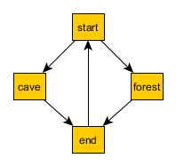

```
$Q start
Go to cave or forest?
$A cave
Go to cave
$A forest
Go to forest

$Q cave
Well, go on..
$A end
Exit cave

$Q forest
Well, go on..
$A end
Exit forest

$Q end
$P cave clr:cave
As you exit the cave, you find...
$P forest clr:forest
As you exit the forest, you find...
$P
...the end of the example.
$A start
Restart
```

This example shows two different routes to a room, and the room's description reacts to where you came from. Note that the room flags are also cleared when the flavor text is shown, so it won't be shown again, should the player end up back on the same page from some other direction later on.

### Lock and Key

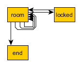

```
$Q room
You're in a room with a door.
$P !key
There is a key here.
$P open
The door is open.

$A room !key set:key
Get key
$A room key !unlocked set:unlocked
Unlock door
$A locked !unlocked !open
Open door
$A room unlocked !open set:open
Open door
$A end open
Exit

$Q locked
The door is locked.
$A room
Dang it!

$Q end
You went through the door.
```

In this example the player needs to take a key, unlock door, open door, and leave. When the player initially reaches this page, the view looks like this:

```
You're in a room with a door.
There is a key here.
----
Get key
Open door
```

The "open door" option shown here does not actually open the door, but sends the player to a page that just says "The door is locked" with the only option of returning back to the page.

If the "Get key" option is picked, the player is sent back to the same page, but with the "key" flag enabled. Now the page looks like this:

```
You're in a room with a door.
----
Unlock door
Open door
```

The "Open door" option is still the same "The door is locked" option. Hitting the "Unlock" option again sends the player back to the same page, now with the "unlocked" flag on.

```
You're in a room with a door.
----
Open door
```

Now the "Open door" option does something different (it's a different "Open door", after all); sending the player back to the same page with the "open" flag on.

```
You're in a room with a door.
The door is open.
----
Exit
```

Finally, the player is given the "Exit" option, which sends the player to the end node, where the game ends.

### Separate Gate

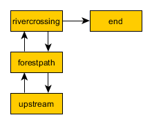

[output not shown]

This example uses several locations. The player has to travel upstream to create a dam in order to be able to cross the river.

### Dialogue

The description-choices structure can also describe dialogue with a non-player character.

```
$Q start
Well hello there. What do you want to know about?
$A name
Name
$A jobs
Jobs
$A virtue
Virtue
```

### Sticky Randoms

In order to keep the result of a random decision, set the result in a flag.

```
$Q coinroom
$P !toss clr:result
$P !toss rnd:64 set:result
$P set:toss
$P result
The coin shows heads.
$P !result
The coin shows tails.

$A coinroom
Look again.
$A coinroom clear:toss
Toss again.
```

In pseudocode, the above becomes:

```
If "toss" is not set:
    Clear "result"
If "toss" is not set, AND random is less than 64:
    Set "result"
Set "toss"
If "result" is set
    Print "The coin shows heads."
If "result" is not set:
    Print "The coin shows tails."
```

### Nerdy Boolean Logic

Freely ignore this if you don't consider yourself a nerd.

In order to AND two flags, simply check both of them at the same time:

```
$O this that
```

In order to OR two flags, check them separately and set a third flag

```
$O this set:thisorthat
$O that set:thisorthat
$O thisorthat
```

In order to exclusively-or two flags, you can use toggle.

```
$O clr:thisxorthat
$O this toggle:thisxorthat
$O that toggle:thisxorthat
```

### Swapping Values

A temporary variable can also be used to swap contents of two numeric variables.

```
$A tavern temp=player_money player_money=stranger_money stranger_money=temp
Swap purses with the stranger
```

Swapping the state of two flags can also be done through a temporary flag, but can not be done on one line.

```
$O clr:t
$O a set:t clr:a
$O b set:a clr:b
$O t set:b
```

## Examples

Here's short overview of some of the examples included in the kit.

### Simple

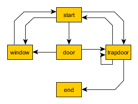

### Complex

The complex example concentrates on the more advanced features of DialogTree, including flag manipulation, and primarily has one heavily self-referential page.

The player needs to put on a light in order to see a key, which the player must pick up, unlock a door, open the door, and then leave.

### Traveller

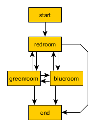

In the traveller example the player is expected to run after a fleeing creature, which hops from one room to the next randomly, with a small chance of it staying put.

This effect is created through a relatively complicated logic. Each room consists of the following kind of structure:

```
$P clr:flip clr:stay
$P rnd:50 set:flip
$P rnd:20 set:stay
$P red !stay flip clr:red set:green
You see Yellow run towards the green room.
$P red !stay !flip clr:red set:blue
You see Yellow run towards the blue room.
$P red
You see a wild Yellow here.
```

First, "flip" and "stay" flags are cleared. Next, "flip" is set 50% of the time, and "stay" is set rather rarely.

Then, if the creature is in this room and is not staying, depending on whether flip is on, the creature is moved from this room to one of the other ones.

If the creature is still in this room after those checks, we announce it.

### Waiting

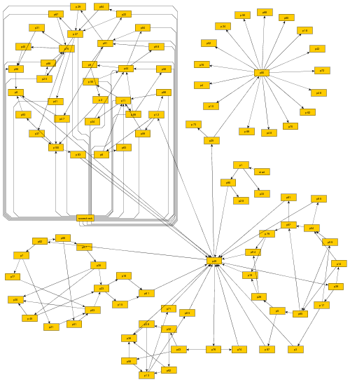

This is the complete "Waiting for the Light" gamebook by Kieran Coghlan, consisting of a hundred locations, flags and numbers, converted to MuCho, the zx spectrum predecessor of DialogTree. The MuCho version was done with persmission of the author.

To understand the structure, let's look at some sub-graphs.

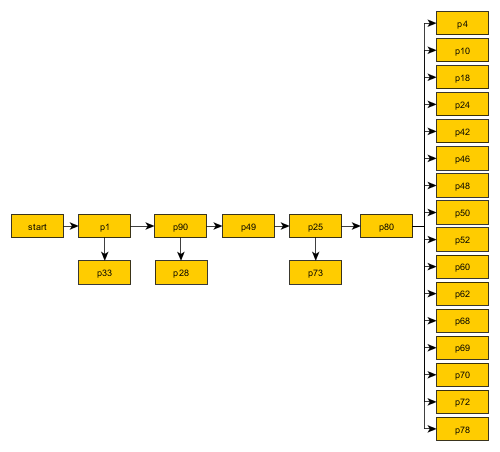

The base structure is as follows: we start, have a couple simple trap choices, then arrive at the hall of lights (page 49), visit some other segments but eventually pick the white light (page 25) which checks if we've gone through all the other segments (via checking the various items), and then presents one of the 16 endings depending on the player choices in the other colored light segments.

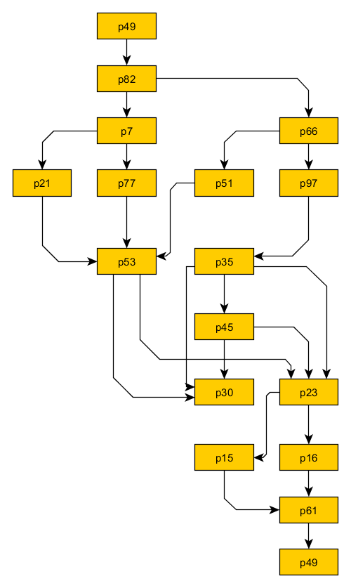

The green segment is relatively simple (in context of this gamebook). Note that the player can die here in a few ways (p30). In the end, the player can either be kill the beast or not (pages 15 and 16).

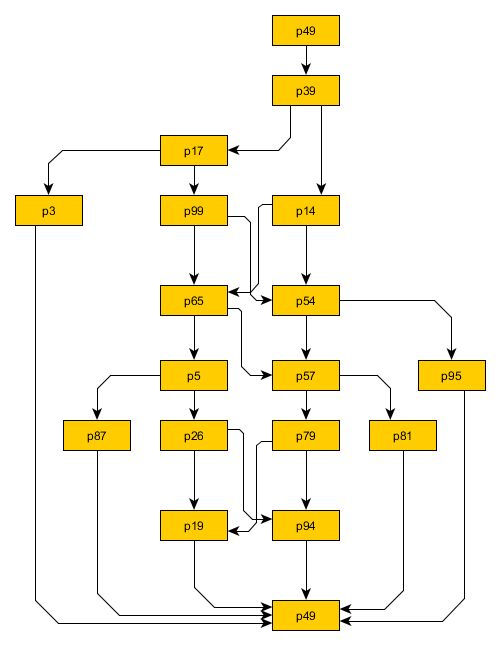

The pink segment represents a relatively complex dialogue. Basically you get to recommend various options, one being a good one and the rest are less so.

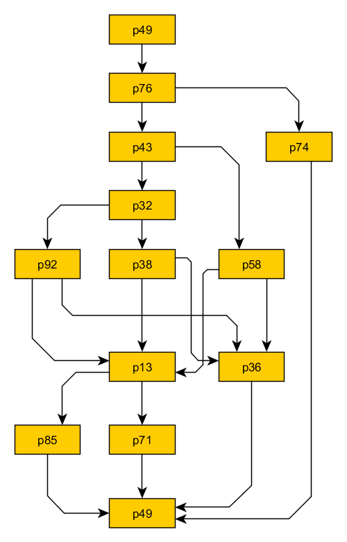

The red segment is again relatively simple, in the end you get to pick whether to be aggressive or not.

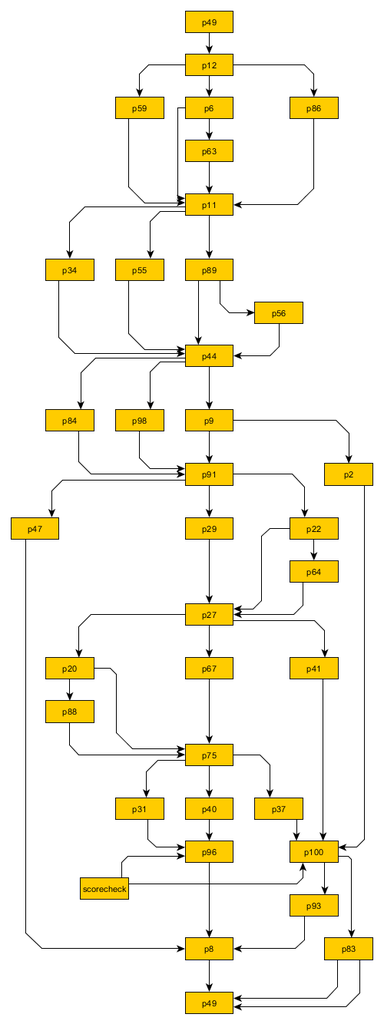

The yellow segment is super complicated: it's a game show. Not only can you answer right or wrong, or let the opponent answer instead, if you get the answers right, you can either take a point or take a card that has various results. And if either you or your opponent reaches 3 points, you hop to an ending.

This uses a subpage to check (and display) the scores and a couple numeric variables to keep the score.

The MuCho zx spectrum version is actually more difficult than the paper version because the player keeps track of the variables in the book version; the spectrum version hides them, so you don't know which result you're getting from your choices until the end.

### Blackjack

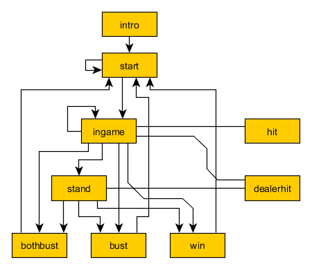

The Blackjack example demonstrates some complex handling of numeric variables. The rules are a bit simplified as compared to actual blackjack; there's no actual card deck, and cards are valued from 0 to 10.

After the intro page the player arrives at the start page where they can choose how much to bet. Note that the game makes sure the player never bets more than they have.

Once a non-zero amount is bet, the player can proceed to the ingame page.

The ingame page does sub-page calls to hit and dealerhit, checks for busts, and asks if player wants to hit or stand, if neither player has gone over 21. If one (or both) players have gone over 21, the player is sent to win, bust, or bothbust pages.

In the stand page there are multiple calls to dealerhit, to make sure the dealer has reached 17 or more. Then the results are checked, and the player is sent to win, bust or bothbust pages. Bothbust is used in case of a tie.

In the bothbust page the player gets the bet back, and is sent back to start to bet again. In the bust page the bet is lost, and we check if player has run out of money, and if so, end the game. There's no separate game over page, we simply won't show the option to start over.

In the win page the player gets their money back twice, and we carefully check if the sum goes over maximum. If it does, we show the good ending text and end the game there. There's no separate game over page in this case either.

The hit and dealerhit pages generate 4 random flags, and then produce a value between 0 and 10 to add to either the player's, or the dealer's, score. Since there are 16 options, 3 of the options give 10 points and 4 of the options give 0 (9+4+3=16). (There's no looping in DialogTree (yet, anyway), so we can't just ignore the zero results and randomize again).

And there you have it - something that approximates blackjack in DialogTree.

# Engine Integration

The DialogTree engine has been implemented in several programming languages, but the basic idea for all is the same; to make using the dialogs as simple as possible. The interfaces follow this pattern:

- Allocate and connect to persistent state
- Load / Use data
- Get question text
- Get number of answers
- Get answer text
- Choose answer
- Cleanup

## Python Engine

tbd

## C Engine

tbd

## C++ Engine

tbd

## JavaScript Engine

tbd